# HW 1: NJ Transit Northeast Corridor

Jonathon Sun

9/19/2021

# Transit Oriented Development and Higher Education Instituions in Mercer and Middlesex County

Higher education institutions have often developed in conjunction with cities. Tate (2008) shows the development of St. Louis and Houston, where highways were built through black communities to help transport white suburbanites to downtown in their cars facilitating white flight. Throughout this process, higher education institutions collaborated with policy makers and business leaders to ensure that their institutions would grow alongside these businesses to become elite schools. This shows the relationship that higher education has to development, but more importantly to modes of transportation. Dache-Gerbino (2016), used GIS and field notes to argue that black students did not have access to higher education institutions, because public transportation options were limited. The role that transportation plays to facilitate higher education are closely linked, and based on this relationship I chose educational attainment, Asian immigration, median household rent, and median household income as indicators to transit oriented development (TOD) in middlesex and mercer county’s NJtransit the northeast regional line.

Asian immigration was specifically selected to understand brain drain out of Asia. The idea of Brain drain is built on human capital theory—the better educated an person is the more productive they will be (Lauder, 2015). China has had a lot of talent leaving the country and as of the early 2000s China has made an effort to pull them back (Zweig & Wang, 2013). In the case that Asians are immigrating to Mercer and Middlesex county in New Jersey, I assume that they will be drawn to regional rail and more educational opportunities. The reason for the assumption behind their eagerness for educational opportunities, is based on US immigration policy focusing on highly skilled immigrants.The assumption being made here is that the amount of foreign Asian people moving into the Mercer and Middlesex county reflects enough of the whole population of the United States to be significant. In this case I am using Chinese and Asian very interchangeably, because in 2018 China replaced Mexico and makes up the third largest group in the United States. Additionally, I do not have access to specifically Chinese immigrant data and the census does not disaggregate the data.

Without going into depth on Asian American history, there are Asian Americans who have been in the US for generations, because their families escaped refugee crises, such as the Korean War or the Vietnam War. However, more recently, the United States has been focusing on skilled labor immigrants. These immigrants often have doctorate and/or professional degrees and the assumption is they would want the opportunity to be near higher education institutions and travel hubs. In the case they are unable to live near a large metropolitan city (such as myself), they would need to live near a regional rail line to access the city.

# Data Wrangling

```r
Search <- c("MEDIAN","INCOME")

VariablesIncome <- load_variables(2019,
                                  "acs5",
                                  cache = TRUE) %>%
                                  filter(grepl("MEDIAN", concept) & grepl("INCOME", concept)) %>%
                                  filter(grepl("Estimate!!Median household income --!!Total:", label)) %>%
                                  slice(1) %>%
  mutate(Merge_name = paste(name,"E", sep ="")) %>%
  mutate(Code = "MedHHIncome")

VariablesIncome$label <- str_remove(VariablesIncome$label, "Estimate!!Total:!!")
VariablesIncome$label <- str_replace(VariablesIncome$label, "!!"," ")
VariablesIncome$label <- str_replace(VariablesIncome$label, ":!!"," ")
VariablesIncome$label <- str_replace(VariablesIncome$label, "--!!Total:"," ")

IncomeVariables00 <- load_variables(2000,
                            "sf3",
                            cache = TRUE) %>%
                            filter(grepl("MEDIAN", concept) & grepl("INCOME", concept)) %>%
                            filter(grepl("Median household income in 1999!!Total", label)) %>%
                            slice(1) %>%
  mutate(Merge_name = paste(name,"E", sep =""))

IncomeVariables00$label <- str_remove(IncomeVariables00$label, "Estimate!!Total:!!")
IncomeVariables00$label <- str_replace(IncomeVariables00$label, "!!"," ")
IncomeVariables00$label <- str_replace(IncomeVariables00$label, ":!!"," ")


IncomeVariables00 <- IncomeVariables00 %>%
  select(-3)


# Asian Foreign Born and Asian International
##  2019

Keep <- c(88,89,93,94,99,100,104,105)
VariablesAsian <- load_variables(2019,
                            "acs5",
                            cache = TRUE) %>%
                            filter(grepl('ASIAN', concept)) %>%
                            slice(Keep) %>%
  mutate(Merge_name = paste(name,"E", sep =""))

VariablesAsian$label <- str_remove(VariablesAsian$label, "Estimate!!Total:!!")
VariablesAsian$label <- str_replace(VariablesAsian$label, "!!"," ")
VariablesAsian$label <- str_replace(VariablesAsian$label, ":!!"," ")
VariablesAsian$label <- str_replace(VariablesAsian$label, "--!!Total:"," ")

Asian_International <- VariablesAsian %>%
  mutate(Sex = ifelse(grepl('Male',label) == TRUE, 'Male', 'Female'),
         Immigrant_status = ifelse(grepl('Native',label) == TRUE, 'Native', 'Foriegn'),
         Age = ifelse(grepl('Under',label) == TRUE, 'Under_18', 'Over_18'),
         Code = paste(substr(Sex,1,1),substr(Immigrant_status,1,1),Age, sep = ""),
         Merge_name = paste(name,"E", sep ="")) %>%
  select(name,Code)

VariablesAsian <- left_join(Asian_International, VariablesAsian, by = "name")


Variables <- rbind(VariablesAsian, VariablesIncome)


## 2000

Variables00 <- rbind(load_variables(2000,
                            "sf3",
                            cache = TRUE) %>%
                            filter(grepl('ASIAN', concept)) %>%
                            filter(grepl('Native', label)) %>%
                       slice(1),
                     load_variables(2000,
                            "sf3",
                            cache = TRUE) %>%
                            filter(grepl('ASIAN', concept)) %>%
                            filter(grepl('Foreign', label)) %>%
                       slice(1)) %>%
  mutate(Merge_name = paste(name,"E", sep =""))

Variables00$label <- str_remove(Variables00$label, "Estimate!!Total:!!")
Variables00$label <- str_replace(Variables00$label, "!!"," ")
Variables00$label <- str_replace(Variables00$label, ":!!"," ")


Variables00 <- Variables00 %>%
  select(-3)

Variables00 <- rbind(IncomeVariables00,Variables00)

# Education Attainment

## 2019

Search <- c("EDUCATION","ATTAINMENT")

VariablesEdu <- load_variables(2019,
                                  "acs5",
                                  cache = TRUE) %>%
                                  filter(grepl("EDUCATION", concept)) %>%
                                  slice(2:6) %>%
  mutate(Merge_name = paste(name,"E", sep =""))

VariablesEdu$label <- str_remove(VariablesEdu$label, "Estimate!!Total:!!")
VariablesEdu$label <- str_replace(VariablesEdu$label, "!!"," ")
VariablesEdu$label <- str_replace(VariablesEdu$label, ":!!"," ")
VariablesEdu$label <- str_replace(VariablesEdu$label, "--!!Total:"," ")

VariablesEdu <- VariablesEdu %>%
  mutate(Code = c("LessHS","HS","SomeCollege","Bachelors","GraduateProfDegree"))

Variables <- rbind(Variables, VariablesEdu)


## 2000

VariablesEdu00 <- load_variables(2000,
                            "sf3",
                            cache = TRUE) %>%
                            filter(grepl("EDUCATION", concept)) %>%
                            mutate(Merge_name = paste(name,"E", sep ="")) %>%
                            slice(28:35,11:18)

VariablesEdu00$label <- str_remove(VariablesEdu00$label, "Estimate!!Total:!!")
VariablesEdu00$label <- str_replace(VariablesEdu00$label, "!!"," ")
VariablesEdu00$label <- str_replace(VariablesEdu00$label, ":!!"," ")
VariablesEdu00$label <- str_remove(VariablesEdu00$label, "Total")
VariablesEdu00$label <- str_replace(VariablesEdu00$label, "!!"," ")

VariablesEdu00 <- VariablesEdu00 %>%
  select(-3)

Variables00 <- rbind(VariablesEdu00,Variables00)

# average rent/mortgage

## 2019

VariablesRent <- load_variables(2019,
                                  "acs5",
                                  cache = TRUE) %>%
                                  filter(grepl("rent", label)) %>%
                                  slice(911) %>%
  mutate(Merge_name = paste(name,"E", sep =""))

VariablesRent$label <- str_remove(VariablesRent$label, "Estimate!!Total:!!")
VariablesRent$label <- str_replace(VariablesRent$label, "!!"," ")
VariablesRent$label <- str_replace(VariablesRent$label, ":!!"," ")
VariablesRent$label <- str_replace(VariablesRent$label, "--!!Total:"," ")

VariablesRent <- VariablesRent%>%
  mutate(Code = "MedRent")


Variables <- rbind(Variables, VariablesRent)


## 2000

VariablesIncome00 <- load_variables(2000,
                            "sf3",
                            cache = TRUE) %>%
                            filter(grepl("rent", label)) %>%
                            mutate(Merge_name = paste(name,"E", sep ="")) %>%
                            slice(67)

VariablesIncome00$label <- str_remove(VariablesIncome00$label, "Estimate!!Total:!!")
VariablesIncome00$label <- str_replace(VariablesIncome00$label, "!!"," ")
VariablesIncome00$label <- str_replace(VariablesIncome00$label, ":!!"," ")
VariablesIncome00$label <- str_remove(VariablesIncome00$label, "Total")
VariablesIncome00$label <- str_replace(VariablesIncome00$label, "!!"," ")

VariablesIncome00 <- VariablesIncome00 %>%
  select(-3)

Variables00 <- rbind(VariablesIncome00,Variables00)

# Total Population
## 2019
VariablesPop <- load_variables(2019,
                                  "acs5",
                                  cache = TRUE) %>%
                                  filter(grepl("Total", label)) %>%
                                  slice(1) %>%
  mutate(Merge_name = paste(name,"E", sep =""))

VariablesPop <- VariablesPop%>%
  mutate(Code = "TotalPop")

Variables <- rbind(Variables, VariablesPop)

## 2000
VariablesPop00 <- load_variables(2000,
                            "sf3",
                            cache = TRUE) %>%
                            filter(grepl("Total", label)) %>%
                            mutate(Merge_name = paste(name,"E", sep ="")) %>%
                            slice(1)

VariablesPop00 <- VariablesPop00 %>%
  select(-3)

Variables00 <- rbind(VariablesPop00,Variables00)
```

# NJ Transit Northeast Regional line

```r
#Link for the actual rail path
NjTransit_Lines <- st_read("https://opendata.arcgis.com/datasets/e6701817be974795aecc7f7a8cc42f79_0.geojson") %>%
      filter(grepl("NORTHEAST", LINE_NAME)) %>%
      select(c("LINE_NAME", "geometry"))%>%
  st_transform(st_crs(acsTractsNJ.2019.sf))
NJtransit <- st_read("https://opendata.arcgis.com/datasets/4809dada94c542e0beff00600ee930f6_0.geojson") %>%
  filter(LINE_CODE == "NE") %>%
  st_transform(st_crs(acsTractsNJ.2019.sf))
```

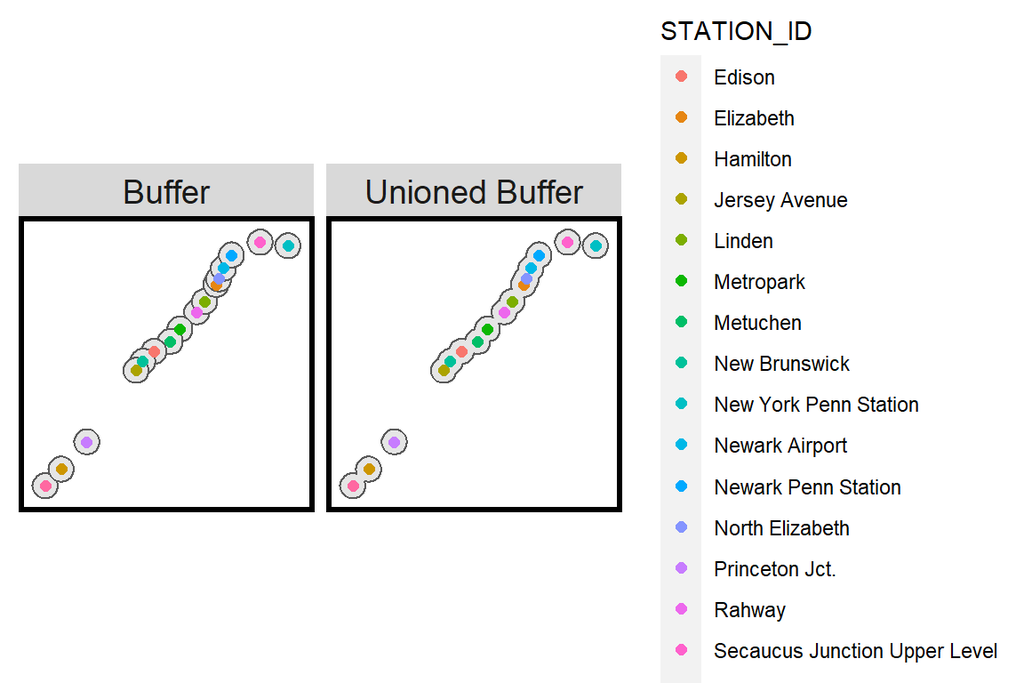

```r
# Creating centroids

#Rather than pick a half mile (2640 feet) I chose to use a 2 mile radius. Since I am working with suburbs, homes are further away from the regional lines.

# Buffers for stations
Buffers <-
  rbind(
    st_buffer(NJtransit, 10560) %>%
      mutate(Legend = "Buffer") %>%
      dplyr::select(Legend),
    st_union(st_buffer(NJtransit, 10560)) %>%
      st_sf() %>%
      mutate(Legend = "Unioned Buffer"))

Buffer <- st_buffer(NJtransit, 10560) %>%
      mutate(Legend = "Buffer") %>%
      dplyr::select(Legend)


Linebuffer <- rbind(
    st_buffer(NjTransit_Lines, 10560) %>%
      mutate(Legend = "Buffer") %>%
      dplyr::select(Legend),
    st_union(st_buffer(NjTransit_Lines, 10560)) %>%
      st_sf() %>%
      mutate(Legend = "Unioned Buffer"))


ggplot() +
  geom_sf(data=Buffers) +
  geom_sf(data = Linebuffer) +
  geom_sf(data=NJtransit,
          aes(colour = STATION_ID),
          show.legend = "point", size= 2) +
  geom_sf(data = NjTransit_Lines) +
  facet_wrap(~Legend) +
  mapTheme()
```

```r
selectCentroids <-
  st_centroid(acsTractsNJ.2019.sf)[Buffers,] %>%
    st_drop_geometry() %>%
    left_join(dplyr::select(acsTractsNJ.2019.sf, GEOID)) %>%
    st_sf() %>%
  mutate(Select_type = "Select by Centroid")
```

## Total Population and Median Rent

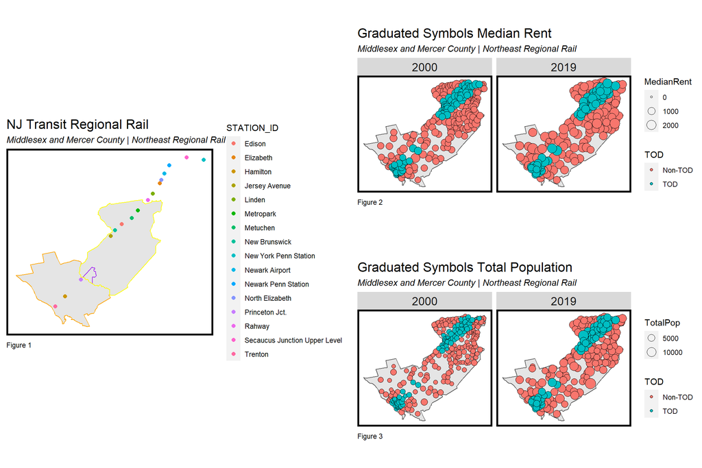

# Distance

Distance to train station can be an important factor. Distance was found using the `multipleringbuffer` argument. Rather then use 1/2 mile increments, I chose to use a larger distance and larger increments. This is to account for the distance between train stations and the spread of neighborhoods in the suburbs in comparison to urban centers.

## Median Rent

I plotted 2000 median rent data and 2019 median rent data over time. As indicated from earlier, even when accounting for inflation the median rent in 2019 is more than in 2000. I also included a line of best fit using the `geom_smooth(method = "lm", se = FALSE)`. This line does indicate that there is a decrease in median rent as census tracts are further from the train station.

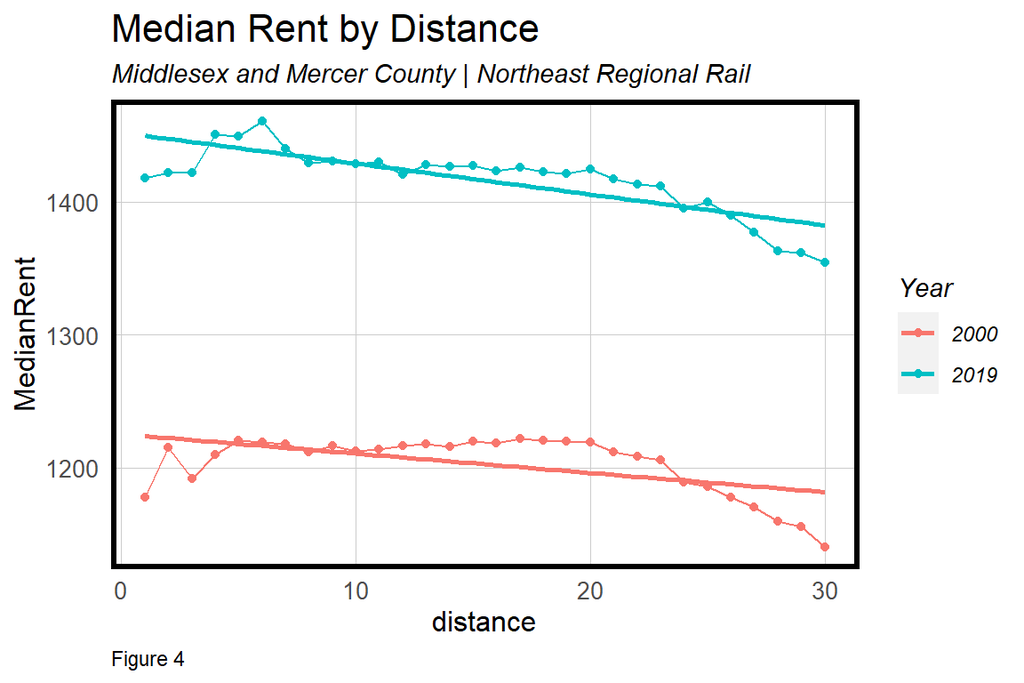

## Median Househould Income

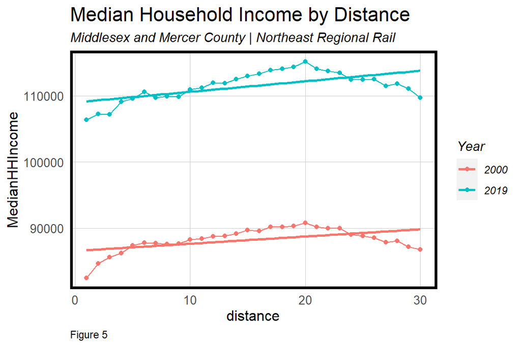

# TOD Indicators

The indicators I will be using are Asian Native, Asian Foreign, median rent, total population, median household income, and educational attainment on four levels.

According to Zweig & Wang (2013), in recent years, China has made an aggressive effort to bring back their citizens who study abroad. In the case that China has been making aggressive efforts to bring back their citizens, that means their citizens must also be wanting to stay in the United States. As stated earlier, the data that is pulled for native and foreign status is specific to Asians. However, due to the limitations of how the census data is organized, I am unable to disaggregate the data. This graph is consistent with the increase in total population, because there was also an increase in foreign and native born Asians in Middlesex and Mercer county. Indicating that the area near the train station is of interest to Asian populations regardless of status.

In regards to rent, the average cost of rent near TOD’s are lower that that of non-TOD’s. This can be interpreted as with low rent, the train station can serve those who lack a vehicle to travel, or the low rent means the land value is low, because there’s a train station and no one wants to live there.

| Variable | 2000: Non-TOD | 2000: TOD | 2019: Non-TOD | 2019: TOD |
| --- | --- | --- | --- | --- |
| Asian_Foreign | 362.20 | 441.85 | 667.51 | 725.28 |
| Asian_Native | 123.97 | 142.39 | 282.12 | 326.33 |
| Bachelor | 581.72 | 492.34 | 797.63 | 635.28 |
| GraduateProfDegree | 394.44 | 350.08 | 602.55 | 511.99 |
| HS | 819.19 | 750.49 | 811.22 | 741.64 |
| Income | 62119.06 | 55090.51 | 112847.48 | 102791.69 |
| Population | 1627.67 | 1548.90 | 4737.47 | 4504.42 |
| Rent | 846.27 | 801.02 | 1498.73 | 1409.84 |
| SomeCollege | 653.54 | 570.89 | 682.07 | 569.94 |

Table 1.2

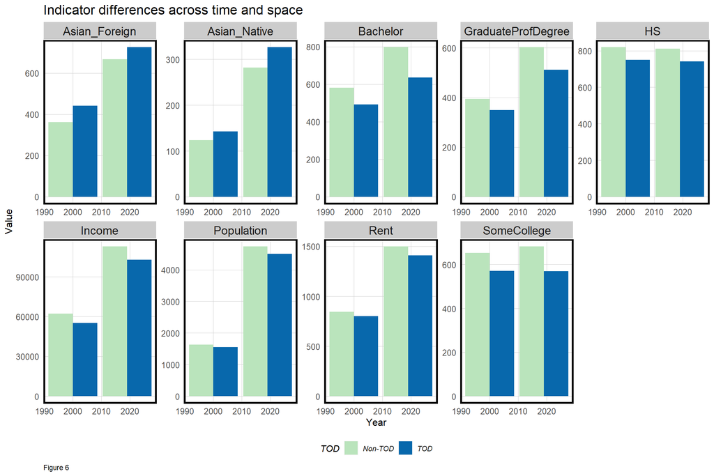

Education is often developed in conjunction with urban centers; however, it is unclear what the relationship that higher education has with subruban development. With Suburban Transit Oriented development in mind, it would make sense that education attainment near transit may be beneficial to education attainment.

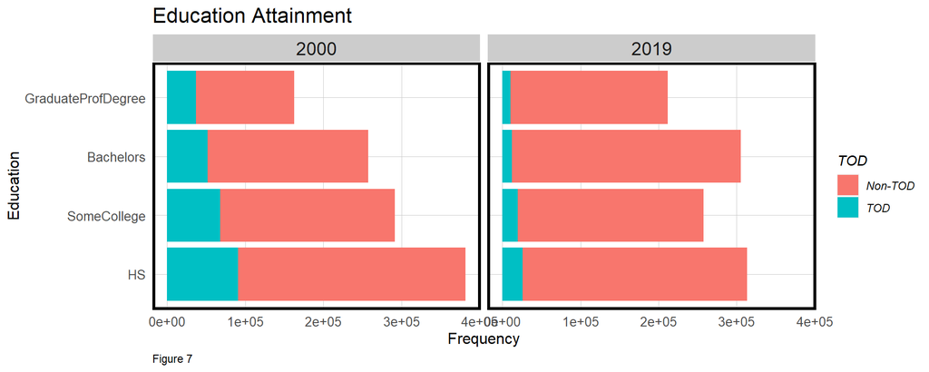

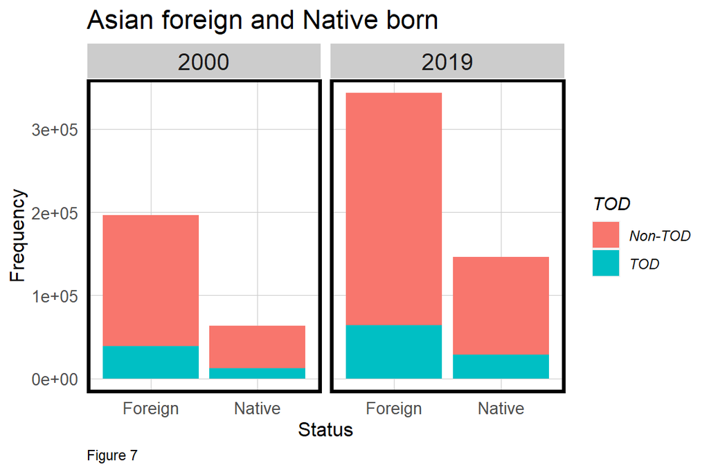

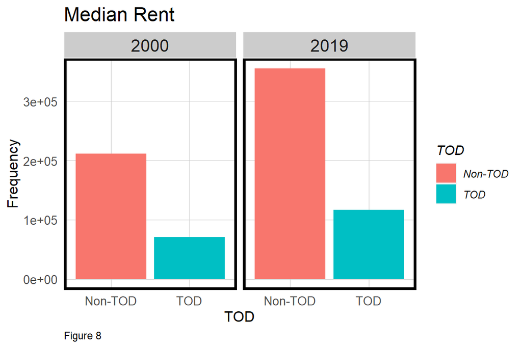

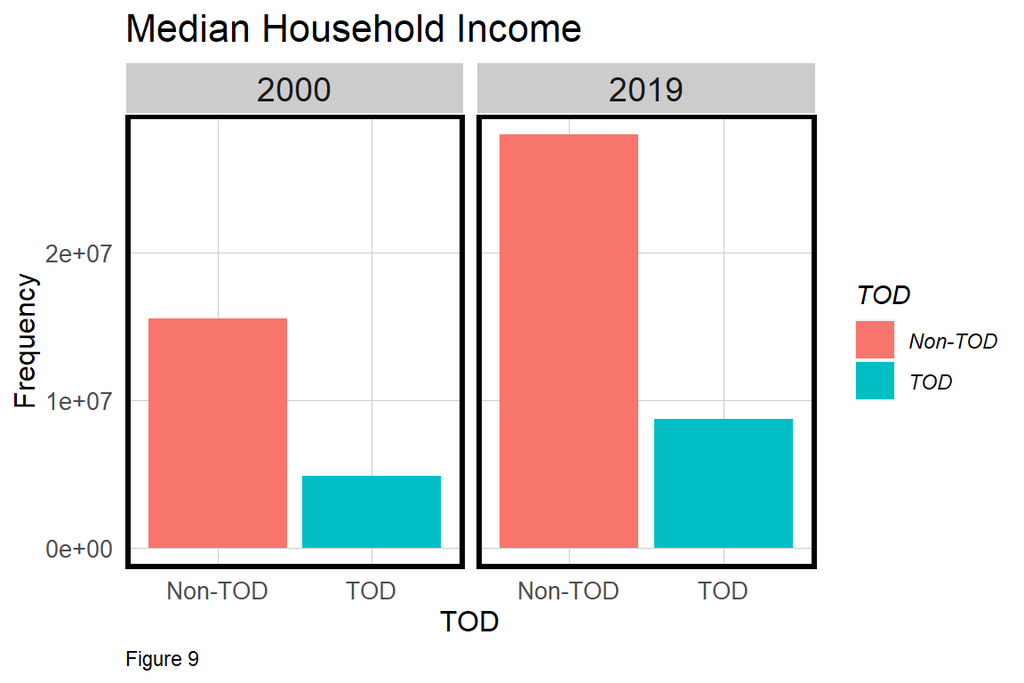

# Universities in Middlesex and Mercer County

Based on literature of higher education and urban development, I had proposed that higher education institutions would benefit from TOD. Using `MedianRent` in the figure below, from 2000 to 2019 there is an increase in the value of property all around New Jersey. To thoroughly answer this question, buffers around the train track can be made to calculate the average median rent around the school compared to the train station and an area away from the train station. Currently with the given data, there does seem to be a visual increase in median rent of census tracts that are near train stations and higher education institutions. What is not clear, is if the increase in median rent in these census tracts are statistically significant from census tracts that do not have a school nearby. Additionally, the schools would also need to count how many train stations are nearby to as the amount of access a school has could shape access to the institution. Lastly, it is unclear whether TOD is specifically drawing students to the institutions for example; did a student select Princeton University over University of Pennsylvania because of the train station on Princeton’s campus?

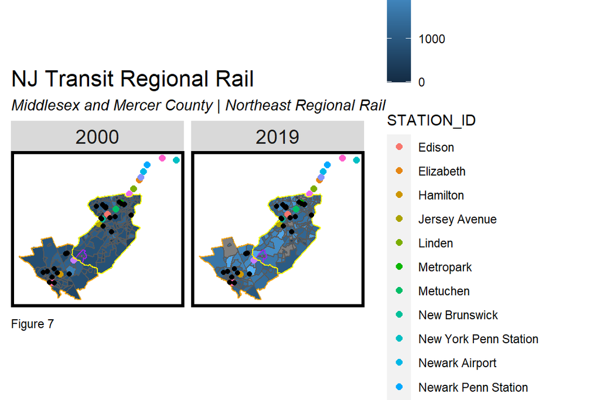

# Conclusion

As this assignment only asks that we find indicators, I hesitate to draw broad conclusions about the indicators included because indicators are a snapshot. Additionally in some cases such as Asian foreign or domestic born, the data is not collected in a way that would appropriately answer the question. Furthermore, specifically relating to higher education institutions, there is not enough data to answer what the connection between TOD and Higher education, if there is one. This data could be supplemented with data from higher education institutions to provide a more robust picture of college access and TOD.

Based on some of the limitations stated, the indicators that were selected are poor indicators. They are not broad enough to provide policy makers a story without needing sufficient context as to their selection. In regards to a research study, there is potential for the data selected to provide a starting point for a study; however, this data would need to be used in conjunction with other data sets and qualitative interviews.

# Sources

Dache-Gerbino, A. (2016). College Desert and Oasis: A Critical Geographic Analysis of Local College Access. *Journal of Diversity of Higher Education*, 1–21. https://doi.org/10.1037/a0021277

Lauder, H. (2015). Human capital theory, the power of transnational companies and a political response in relation to education and economic development. *Compare: A Journal of Comparative and International Education*, *45*(3), 490–493. https://doi.org/10.1080/03057925.2015.1027515

Tate, W. F. (2008). œGeography of Opportunity”: Poverty, Place, and Educational Outcomes. *Educational Researcher*, *37*(7), 397–411. https://doi.org/10.3102/0013189x08326409

Zweig, D., & Wang, H. (2013). Can China Bring Back the Best? The Communist Party Organizes China’s Search for Talent. *The China Quarterly*, *215*, 590–615. https://doi.org/10.1017/S0305741013000751